# Statystyka: przykładowa analiza ankiety

Tomasz Przechlewski

Powiślańska Szkoła Wyższa (Kwidzyn/Poland)  
t.plata-przechlewski@psw.kwidzyn.edu.pl

Jan. 2021

## Uwagi ogólne

Badanie dotyczy strachu i samosktuteczności. Czy większa samoskuteczność skutkuje większym strachem czy odwrotnie. Czy strach zależy od płci, stażu i wielkości firmy?

Przed wyżej wymienioną zasadniczą analizą należy scharakteryzować respondentów względem cech demograficzno-społeczno-ekonomicznych, w naszym przypadku: płeć, staż, wielkość firmy.

W poniższym opisie tekst w nawiasach […] to wskazówki dotyczące zastosowanej metody.

Formularz ankiety jest tutaj: https://docs.google.com/forms/d/e/1FAIpQLSe978MLywUaAomO8BmD1_VsXdOzbV5cVtiIqbFQhurhtxFQKQ/viewform?usp=sf_link

Wszystkie zastosowane metody statystyczne są dostępne w arkuszu LibreOffice w menu Dane → Statystyka.

## Charakterystyka badanych respondentów

## Badani wg płci

| płeć | n | % |
| --- | --- | --- |
| K | 166 | 87.36842 |
| M | 24 | 12.63158 |

Wykres słupkowy:

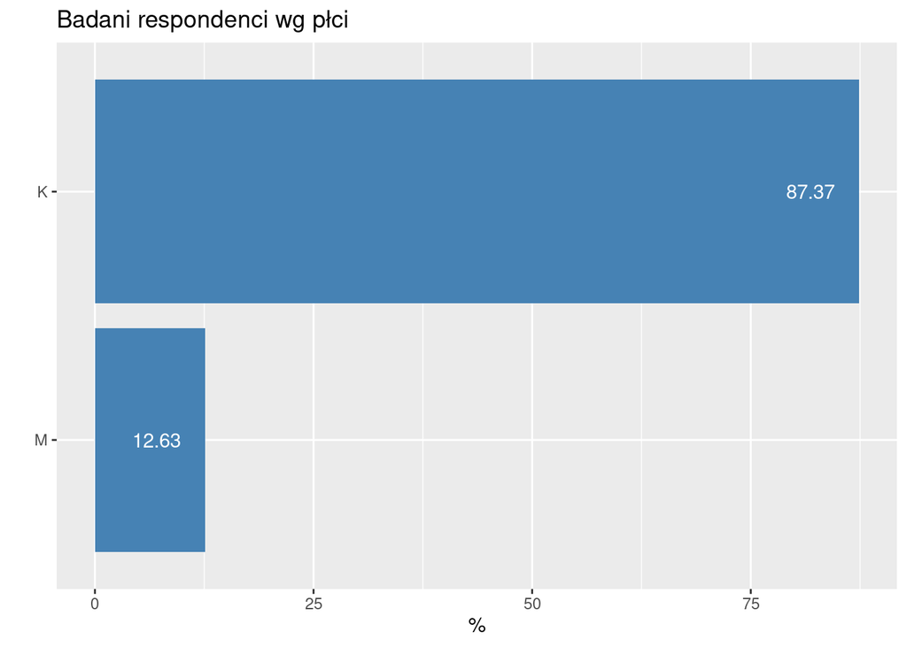

## Badani wg wielkość firmy

[Jak wg płci tylko zmienną grupującą jest zatrudnienie w firmie w której pracuje respondent]

| zatrudnienie | n | % |
| --- | --- | --- |
| 1 | 2 | 1.052632 |
| 10-49 | 67 | 35.263158 |
| 50 i więcej | 109 | 57.368421 |
| do 9 osób | 12 | 6.315790 |

Zatrudnionych w firmach < 10 jest na tyle mało że warto zmienić podział na firmy do 50 zatrudnionych oraz większe:

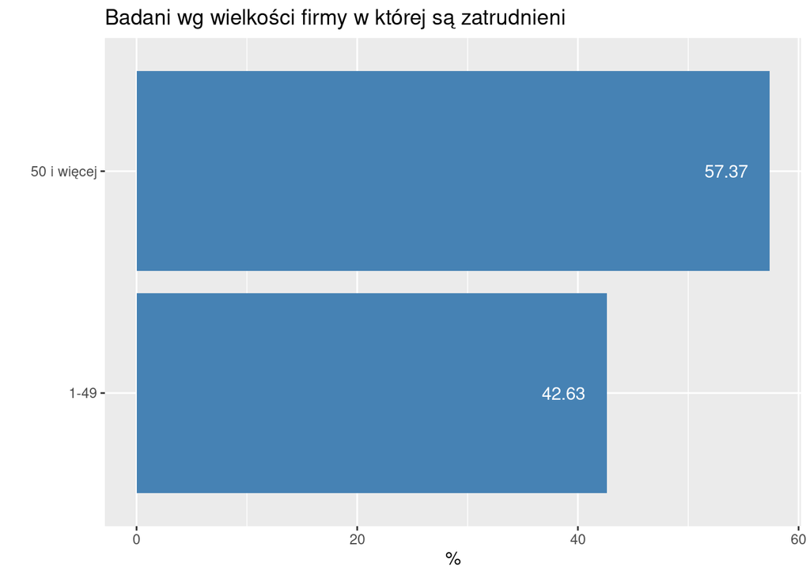

Większość respondentów (57%) pracuje w firmach dużych (50 i więcej zatrudnionych.)

## Badani wg stażu

[analizowana zmienna mierzona jest w skali liczbowej: rysujemy histogram oraz liczymy miary średnie, rozproszenia i asymetrii.]

Średni staż respondentów wnosił 18.9473684 lat. Połowa respondentów przepracowała 21 lat i mniej, a połowa 21 lat i więcej [interpretacja mediany]. Dość znaczna różnica między średnią a medianą wskazuje na znaczącą asymetrię lewostronną.

Przeciętne odchylenie od średniej wyniosło 9.6311536 lat, wielkość rozstępu międzykwartylowego 15 lat (odchylenie ćwiartkowe 7.5 lat).

Skośność -0.3626402 (albo różnica między średnią a medianą, podzielona przez odchylenie standardowe): -0.2131242 jest ujemna ale niewielka.

Histogram (szerokość przedziału 5 lat):

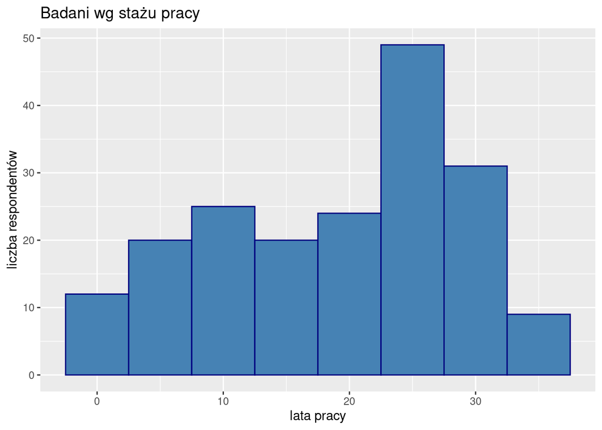

## Badani według stażu pracy oraz płci

[Można przeprowadzić bardziej szczegółową analizę respondentów łącznie w oparciu o dwie zmienne, np staż i płeć. Ponieważ staż jest mierzony na skali liczbowej można porównać średnie wartości stażu dla kobiet oraz mężczyzn.]

Średnie wielkości stażu według płci respondentów zestawiono w tabeli:

| płeć | średni staż | mediana stażu |
| --- | --- | --- |
| K | 19.95181 | 23.0 |
| M | 12.00000 | 12.5 |

## Zasadnicza część badania: strach a samoskuteczność, staż, płeć itd…

## Strach a płeć respondentów

[Czy strach zależy od płci (test chi-kwadrat niezależności)?]

Ponieważ strach jest mierzony na skali liczbowej przed zastosowaniem testu przekodowujemy go na skalę porządkową (duży 25–35; średni 15–24; mały 14 i mniej)

Tablica wielodzielna

|  | K | M |
| --- | --- | --- |
| duży | 15 | 0 |
| mały | 33 | 7 |
| średni | 118 | 17 |

Test chi-kwadrat z hipotezą zerową: strach i płeć są niezależne:

```
## [1] 0.2200367
```

Wartość prawdopodobieństwa 0.2200367 oznacza że nie ma podstaw do odrzucenia hipotezy o niezależności zmiennych strach i płeć (co oznacza że nie ma związku między tymi cechami)

## Strach a samoskuteczność

[obie zmienne są liczbowe możemy zastosować model regresji liniowej]

$$\mathrm{strach} = b \cdot
\mathrm{samoskuteczność} + a$$

```
## (Intercept)          se
##  23.4099602  -0.1357599
```

Po oszacowaniu parametrów metodą najmniejszych kwadratów otrzymujemy b = -0.1357599; a = 23.4099602. Interpretacja: jednostkowy wzrost samoskuteczności skutkuje zmniejszeniem strachu o 0.1357599, ale dopasowanie modelu jest bardzo słabe. Współczynnik determinacji $R^2 = $ 1.8914281%. Tak niska wartość $R^2$ oznacza że nie ma (liniowego) związku między strachem a samoskutecznością.

Wykres rozproszenia + linia regresji:

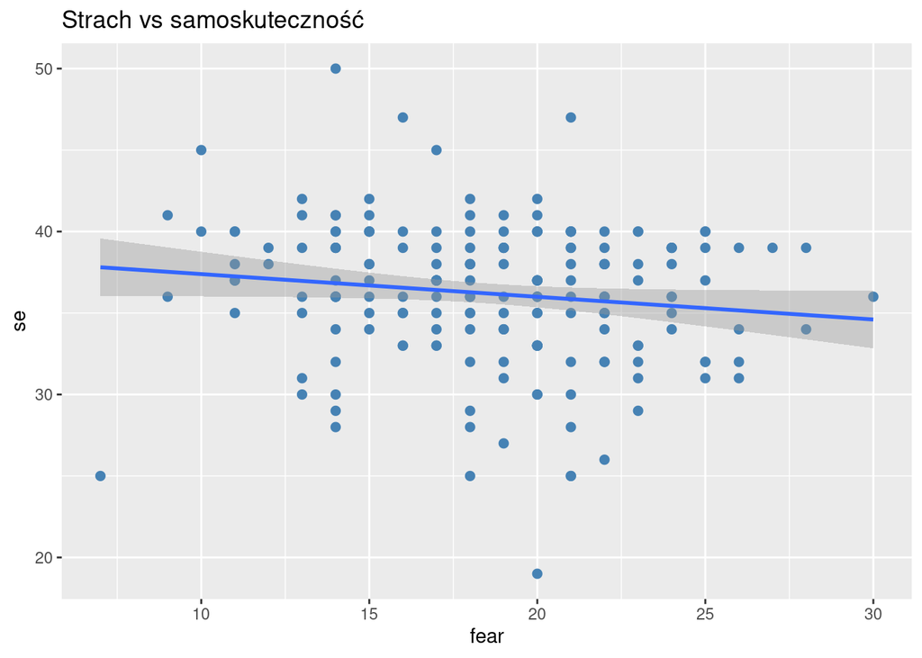

Z uwagi na bardzo słabe dopasowanie można stwierdzić że nie ma związku między strachem a samoskutecznością

[Zamiast regresji można porównać średnie w grupach. W tym celu ponieważ samoskuteczność jest mierzona na skali liczbowej przekodowujemy ją na skalę porządkową, tworząc następujące grupy: ‘duża’ > 40; ‘średnia’ 30–39; ‘mała’ 20–29, ‘bardzo mała’ 19 i mniej]

| samoskuteczność | średni strach |
| --- | --- |
| b. mała | 20.00000 |
| duża | 17.14634 |
| mała | 18.00000 |
| średnia | 18.93382 |

Niewielkie różnice między średnimi świadczą o tym że nie ma związku pomiędzy samoskutecznością a strachem.

Można także oceniać zależność pomiędzu strachem i samoskutecznością obliczając współczynnik korelacji (liniowej) Pearsona

```
## [1] -0.1375292
```

```
##
##  Pearson's product-moment correlation
##
## data:  d1$fear and d1$se
## t = -1.9038, df = 188, p-value = 0.05846
## alternative hypothesis: true correlation is not equal to 0
## 95 percent confidence interval:
##  -0.274508277  0.004920456
## sample estimates:
##        cor
## -0.1375292
```

Wartość jest prawie istotna na poziomie 5% (istotna na poziomie 10%) o czym świadczy wartość prawdopodobieństwa (`p-value` = 0,05846)

## Strach a staż

[także model regresji]

```
## (Intercept)          ex
## 17.01522915  0.07808513
```

Po oszacowaniu parametrów metodą najmniejszych kwadratów otrzymujemy b = 0.0780851; a = 17.0152292. Interpretacja: wzrost stażu o rok skutkuje wzrostem strachu o 0.0780851 (w jednostkach skali mierzącej strach), ale dopasowanie modelu jest znowu bardzo słabe. Współczynnik determinacji $R^2 = $ 3.1333606%. Tak niska wartość $R^2$ oznacza że nie ma (liniowego) związku między strachem a stażem.

Wykres rozproszenia + linia regresji:

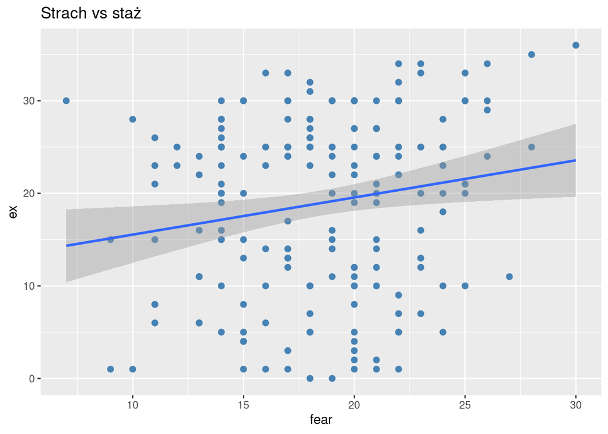

**[Koniec]**